# Chapter2 slides

## Objetivos del capítulo

En este capítulo revisaremos:

- Primera Parte
  - Funciones
  - If else, elif
  - For loop
  - While Loop
- Segunda Parte
  - Numpy
  - Matplotlib

## Funciones

- Las funciones son la base del **procedural programming paradigm".
- Permiten dividir el programa en partes más pequeñas. **Modularidad**
- Reutilización del código. Las funciones pueden ser llamadas varias veces.
- Manejable. Un programa divido en funciones es más fácil de **debug**
- Pueden o no tener argumentos
- pueden o no devolver un resultado

```python
def imprimir_hola():
    print('hola')

imprimir_hola()
```

```
hola
```

```python
def imprimir_mi_nombre(nombre):
    print('Mi nombre es {}'.format(nombre))

imprimir_mi_nombre('Rumpelstiltskin')
```

```
Mi nombre es Rumpelstiltskin
```

```python
from math import pow, sqrt
def hipotenusa(cateto_1, cateto_2):
    return sqrt(pow(cateto_1,2)+pow(cateto_2,2))
hipotenusa(3.,4.)
```

```
5.0
```

# IF - Else - Elif

Para aprobar un curso se require de un minimo de 70% de la nota. Si la nota ingresada es mayor a este valor imprima **aprobado** sino **rechazado**

```python
nota = input('Digite un numero entre 0 - 100: ')
if int(nota) > 70:
    print('Aprobado')
else:
    print('Falla')
```

```
Digite un numero entre 0 - 100: 45
Falla
```

```python
nota = input('Digite un numero entre 0 - 100: ')
if int(nota) > 70:
    print('Aprobado')
print('Falla')
```

```
Digite un numero entre 0 - 100: 22
Falla
```

Se desea implementar un indicador de temperatura de 3 niveles para un motor trifásico. Sea temperatura el nombre de la variable de tipo real

- Si temperatura mayor a 40: "Peligro"
- Si temperatura entre 10 a 40: "Normal"
- Si temperatura menor a 10: "Revisar humedad interna motor"

```python
temperatura = float(input('Ingrese el valor de temperatura: '))
if temperatura > 40.0:
    print('Peligro, incrementar refriegeración forzada en el motor')
elif temperatura >= 10.0 and temperatura <=40.0:
    print('Estado Normal')
else:
    print('Revisar humedad interna del motor')
```

```
Ingrese el valor de temperatura: hola
```

```
---------------------------------------------------------------------------
ValueError                                Traceback (most recent call last)
<ipython-input-9-f4170089fb8e> in <module>
----> 1 temperatura = float(input('Ingrese el valor de temperatura: '))
      2 if temperatura > 40.0:
      3     print('Peligro, incrementar refriegeración forzada en el motor')
      4 elif temperatura >= 10.0 and temperatura <=40.0:
      5     print('Estado Normal')

ValueError: could not convert string to float: 'hola'
```

## Try and Catch

Cuando necesitamos atrapar los errores en un programa, usamos la sentencia **Try**. Por ejemplo, si en el programa anterior ingresamos una cadena de caracteres en vez de un numero, la operación *float(temperatura)* va a fallar

Revise la documentación disponible en: https://docs.python.org/3/tutorial/errors.html

```python
try:
    temperatura = float(input('Ingrese el valor de temperatura: '))
    if temperatura > 40.0:
        print('Peligro, incrementar refriegeración forzada en el motor')
    elif temperatura >= 10.0 and temperatura <=40.0:
        print('Estado Normal')
    else:
        print('Revisar humedad interna del motor')
except ValueError:
    print('Valor ingresado no es un número')
```

```
Ingrese el valor de temperatura:
Valor ingresado no es un número
```

## Ejercicio

Simplifique el programa anterior utilizando funciones

## For Loop:

En python el lazo for es distinto al de *C* y generalmente opera sobre listas

```python
lista_nombres = ['Ana','Alvaro', 'Ariana', 'Annabel']

for nombre in lista_nombres:
    print(nombre)
```

```
Ana
Alvaro
Ariana
Annabel
```

```python
n = int(input('Ingrese un numero entero '))
rango_numeros = range(n)

def es_par(numero):
    if numero%2 ==0:
        return True
    else:
        return False

for numero in rango_numeros:
    if es_par(numero=numero):
        print(numero)
    else:
        continue
```

```
Ingrese un numero entero 15
0
2
4
6
8
10
12
14
```

## For loop en formato funcional

Este formato tiene la ventaja de reducir el numero de lineas de código. Suponga que deseamos obtener a partir de una lista de numeros aleatorios sus respectivos cuadrados.

```python
from random import randint
size_list = int(input('Ingrese el tamano de la lista'))

arreglo_original= [ randint(0,100) for i in range(size_list)]
arreglo_original
```

```
Ingrese el tamano de la lista10
```

```
[57, 78, 33, 18, 40, 80, 3, 0, 2, 95]
```

```python
arreglo_cuadrado = [ numero**2 for numero in arreglo_original]
arreglo_cuadrado
```

```
[3249, 6084, 1089, 324, 1600, 6400, 9, 0, 4, 9025]
```

## While Loop

Ejecución de una rutina mientras es verdadera

```python
n = int(input('Ingrese un numero entero '))
cont = 0
while(cont<n):
    print('{} es menor a {} '.format(cont, n))
    cont+=1
```

```
Ingrese un numero entero 5
0 es menor a 5
1 es menor a 5
2 es menor a 5
3 es menor a 5
4 es menor a 5
```

## Ejercicios

- Escribir una función que verifique si un numero es primo o no
- Escribir una función factorial
- Escribir una función que verifique si un numero es primo de Sheldon
- Dado un arreglo de numeros enteros ordenarlos

## Zen of python

[figure not shown]

## Numpy - Numerical Python

- Permite realizar operaciones matriciales similares a las realizables con Matlab
- Permite realizar: operaciones multidimensionales, lógicas, algebra lineal, transformadas de fourier, entre otras
- Puede utilizar tipos de datos int8, int16, int32 int64, float16, float32, float64, uint8, uint16, uint32

```python
import numpy as np
array1 = np.array([1,2,3,4])
matriz = np.matrix([[1,2,3], [4,5,6]])
print('arreglo {}'.format(array1))
print('matriz \n {} '.format(matriz))
```

```
arreglo [1 2 3 4]
matriz
 [[1 2 3]
 [4 5 6]]
```

```python
a = np.matrix('1 2 3 ; 4 5 6; 7 8 9')
a
```

```
matrix([[1, 2, 3],
        [4, 5, 6],
        [7, 8, 9]])
```

```python
b = np.matrix('1 2 3 ; 4 5 6; 7 8 9', dtype=str)
b
```

```
matrix([['1', '2', '3'],
        ['4', '5', '6'],
        ['7', '8', '9']], dtype='<U1')
```

```python
c = np.arange(0,10,2, dtype=np.float32)
c
```

```
array([0., 2., 4., 6., 8.], dtype=float32)
```

```python
arreglo = np.linspace(0,10, 10)
arreglo
```

```
array([ 0.        ,  1.11111111,  2.22222222,  3.33333333,  4.44444444,
        5.55555556,  6.66666667,  7.77777778,  8.88888889, 10.        ])
```

```python
mat_a = np.random.rand(5,5)
mat_a
```

```
array([[0.29781994, 0.56418264, 0.30939084, 0.38419085, 0.77670567],
       [0.63081208, 0.80897464, 0.67771148, 0.2070571 , 0.16441434],
       [0.82124818, 0.73041728, 0.20749951, 0.14371113, 0.88724438],
       [0.48732753, 0.86933096, 0.95251085, 0.75384575, 0.22705426],
       [0.2058425 , 0.27761099, 0.42665696, 0.55439317, 0.20970712]])
```

```python
mat_a = np.asmatrix(mat_a)
mat_a
```

```
matrix([[0.29781994, 0.56418264, 0.30939084, 0.38419085, 0.77670567],
        [0.63081208, 0.80897464, 0.67771148, 0.2070571 , 0.16441434],
        [0.82124818, 0.73041728, 0.20749951, 0.14371113, 0.88724438],
        [0.48732753, 0.86933096, 0.95251085, 0.75384575, 0.22705426],
        [0.2058425 , 0.27761099, 0.42665696, 0.55439317, 0.20970712]])
```

## Aplicando funciones integradas en Numpy

```python
arreglo = np.arange(0,10,1)
arreglo
```

```
array([0, 1, 2, 3, 4, 5, 6, 7, 8, 9])
```

```python
x = np.sum(arreglo)
x
```

```
45
```

```python
x = np.mean(arreglo)
x
```

```
4.5
```

```python
x = np.max(arreglo)
x
```

```
9
```

```python
x = np.std(arreglo)
x
```

```
2.8722813232690143
```

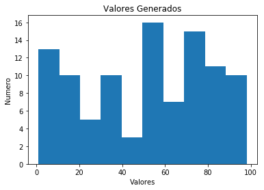

```python
arreglo2 = np.random.randint(0, 100, 100)
import matplotlib.pyplot as plt
plt.hist(arreglo2)
plt.title('Valores Generados')
plt.xlabel('Valores')
plt.ylabel('Numero')
plt.show()
```

## Ejercicios

- Declare dos arreglos lineales y obtenga el producto escalar de los mismos. Resuelva con numpy y con una funcion propia
- Declare dos matrices $A$ y $B$ de tamaños $m$ y $n$ donde $m \neq n$ y obtenga: $A+B$, $A*B$, $A.*B$

## Matplotlib

La librería de python que permite graficar resultados e imágenes similar a Matlab

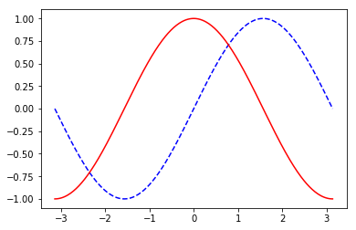

```python
x =np.linspace(-np.pi, np.pi, 300)
y1, y2 = np.sin(x), np.cos(x)
plt.figure()
plt.plot(x, y1, color='blue', linestyle='--')
plt.plot(x, y2, color='red', linestyle='-')
plt.show()
plt.savefig('images/SinCos.png', dpi=180)
```

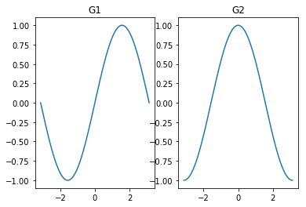

```python
plt.figure()
plt.subplot(1,2,1)
plt.plot(x,y1)
plt.title('G1')
plt.subplot(1,2,2)
plt.plot(x,y2)
plt.title('G2')
plt.show()
```

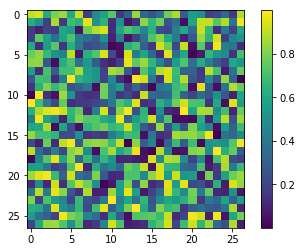

```python
img = np.random.random((27,27))
plt.imshow(img)
plt.colorbar()
plt.show()
```

# Referencias Adicionales

- http://cs231n.github.io/python-numpy-tutorial/